Proposal for Preventive Maintenance --- Predicting RUL 預測性维护項目建议 --- 预测 RUL

- Assume these engines are our company's assets
- 假设这些引擎是我们公司的资产

# Overview 概述

These engines are our most valuable and mission critical assets. The optimal goals are maximize our engine operation cycles while keep our engines in good and oprational shape; which directly affects our company's bottom line.

There are many other optational optimization process that can help to achive these goals. What we are proposing is to make use of the data (sensor readings and operation settings) collected in the past years. Using machine learning technologies, we aim to build AI models to predict remaining useful lifetime for our engines.

Once we develop the AI models, we will build an end-to-end production pipeline to collect and process engine data, execute AI models and generate actionable insights and reports. Our end-to-end pipeline also includes procedures/processes that evaluate and measure the performance of our AI models so that these models can best handle current signal/process data.

这些引擎是我们最有价值和最关键的资产。最佳目标是最大化我们的发动机运行周期，同时保持我们的发动机处于良好和可操作的状态；这直接影响到我们公司的底线。

还有许多其他可选优化过程可以帮助实现这些目标。我们提议的是利用过去几年收集的数据（传感器读数和操作设置）。使用机器学习技术，我们的目标是建立人工智能模型来预测我们引擎的剩余使用寿命。

一旦我们开发了人工智能模型，我们将建立一个端到端的生产管道来收集和处理引擎数据、执行人工智能模型并生成可操作的见解和报告。我们的端到端管道还包括评估和测量我们的 AI 模型性能的程序/流程，以便这些模型能够最好地处理当前的信号/流程数据。

# Problem Statement 问题陈述

The problem at hand is to come up with a machine learning model to predict RUL based on time-series data of sensor measurements which our operation team have been collecting for the past N years for our engines. 建造机器学习模型，以根据我们的运营团队在过去 N 年中为我们的引擎收集的传感器测量的时间序列数据来预测 RUL。

# Data and Dependencies 数据和依赖项

```python
import sys
import os
current = os.getcwd()
parent_folder = os.path.abspath(os.path.join(os.getcwd(), os.pardir))

sys.path.insert(0, f"{parent_folder}\Classes")
from menu_A_a_data_utility import DataUtility
from IPython.display import display, Image, Markdown
```

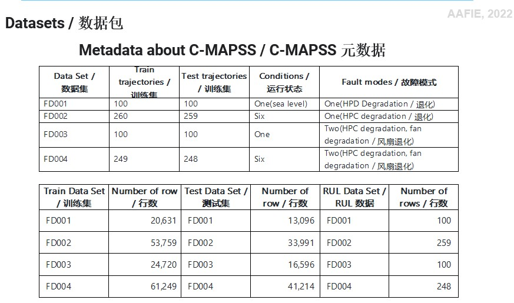

```python
Image(parent_folder+r"\Classes\gifs\data.jpg")
```

- We use the above data on our phase one (model building). 我们在第一阶段（模型构建）中使用上述数据。

## Dependencies:

Once the models are built, we will work with Operation department for near-real time data collection pipeline.

## 依赖：

模型建成后，我们将与运营部门合作进行近乎实时的数据收集管道。

# Approach and Phases 方法和阶段

## Aproach 方法

- Our IT dev/ds team will work together buidling conventional ML and Deep learning models.
- We have a plan to reach out to **Institute**, Professor Niu and team, to exame and validate our ml approaches on these mission critical models. Proper DNA have already prepared.
- 我们的 IT 开发/ds 团队将共同构建传统的 ML 和深度学习模型。
- 我们计划与**Institute**、牛教授和团队联系，以检查和验证我们在这些关键任务模型上的机器学习方法。 适当的 DNA 已经准备好。

## General Flow 一般流程

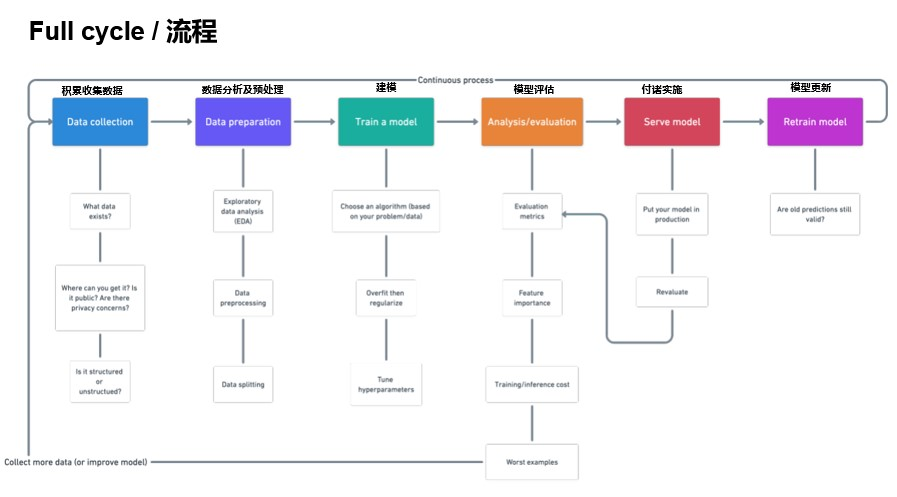

```python
Image(parent_folder+r"\Classes\gifs\flow.jpg")
```

## Phases: 阶段：

- Phase I. EDA and Feature research. Problem statement digest.
  1. Deliverable from Phase I:  
     a. Descriptive report of EDA and feature research.  
     b. Metrics and Success Criteria and discuss with Management team.
  2. Time Line:  
     Team A for 2 weeks.
- Phase II: Building Models.
  1. Deliverable from Phase II:  
     a. Regression models  
     b. DNN models
     1. Time Line:  
        Team A for 2 weeks.
- Phase III: Streaming and Pipeline. Model deployment.
  1. Deliverables from Phase III:  
     a. data collection and processing pipeline  
     b. Model deployed.  
     c. Dashboard and/or Notification pipeline
  2. Time Line:  
     a. Team A and B for 2 weeks.
  3. Success criteria: May need to refine models and repeat Model Building tasks.
- Phase IV: Productionization.
  1. Deliverables from Phase IV:  
     a. Operation/Support documenation for this ML project  
     b. Training and workshop for end-users
  2. Time Line:  
     a. Team A and B for 1 weeks.
- Detailed schedule plan attached
- 第一阶段。EDA 和特征研究。问题陈述摘要。
  1. 第一阶段的可交付成果：  
     一个。 EDA 和特征研究的描述性报告。  
     湾。指标和成功标准，并与管理团队讨论。  
     2.时间线：  
     A队2周。
- 第二阶段：建筑模型。
  1. 第二阶段的可交付成果：  
     一个。回归模型  
     湾。 DNN 模型  
     2.时间线：  
     A队2周。
- 第三阶段：流媒体和管道。模型部署。
  1. 第三阶段的可交付成果：  
     一个。数据收集和处理管道  
     湾。已部署模型。  
     C。仪表板和/或通知管道  
     2.时间线：  
     一个。 A 组和 B 组为期 2 周。
  2. 成功标准：可能需要细化模型并重复建模任务。
- 第四阶段：生产化。
  1. 第四阶段的可交付成果：  
     一个。此 ML 项目的操作/支持文档  
     湾。最终用户培训和研讨会  
     2.时间线：  
     一个。 A组和B组1周。 *附上详细的日程安排

# Features / 項目結果

- Our final dashboard will look this :
- detailed explanation attached.
- 我们的最终仪表板将如下所示： *附上详细说明。

[figure not shown]

```python
Image(parent_folder+r"\Classes\gifs\feature.jpg")
```

- In addtion, we will also build a email notification pipeline for Anomaly notification.

# Risks and Blockers. Contingency Plan 风险和阻碍。 应急计划

- The project is not without risks. Possibly:
  1. Our models may need work well with current data. the data we have is of N years old.
  2. We don't have a good method to tracking our in coming new engines.
- Contingency Plan:
  1. while we building models on previous data. We will work together with Operation team to get as much data as we can and compare the data sets.
  2. For new models, we will reach out manufacturers/suppliers to learn more about these new engines.

该项目并非没有風險。 可能性：

我们的模型可能需要很好地处理当前数据。 我们拥有的数据已有 N 年历史。 我们没有很好的方法来跟踪我们即将推出的新引擎。 应急计划：

而我们在以前的数据上建立模型。 我们将与运营团队合作，尽可能多地获取数据并比较数据集。 对于新车型，我们将联系制造商/供应商以了解有关这些新发动机的更多信息。

# Metrics and Success Criteria. Exit Plan 指标和成功标准。 退出计划

## Metrics and Success Criteria. 指标和成功标准。

- We propose the following Metrics for success:
  1. Number of Mainteances reduced by N%
  2. Engine cycles between maintenace increase by M%
  3. Overall mainteance cost per Engine decrease by P%
- 我们提出以下成功指标：
  1. 维护次数减少 N%
  2. 发动机保养周期增加 M%
  3. 每台发动机的总体维护成本降低了 P%

## Exit Plan 退出计划

- After each Phase, the project will be reviews together with Management team. Upon execution status, may suspend and/or refined.
- 在每个阶段之后，项目将与管理团队一起进行审查。 在执行状态下，可以暂停和/或细化。

# Team / Resources 团队/资源

## DS Team DS 团队

```
1. Engineer 工程师 1, 2, 4.
```

## Dev Team Dev 团队

```
1. Engineer 工程师 6,9
```

## PM and Key Project Liason PM和重点项目联络人

```
1. PM 7, 12
```

## Resources Requirement 资源需求

[output not shown]

ABC Company Confidental ABC 公司机密